# RNA-seq HOMEWORK

Aleksandra Kurowska

January 27, 2024

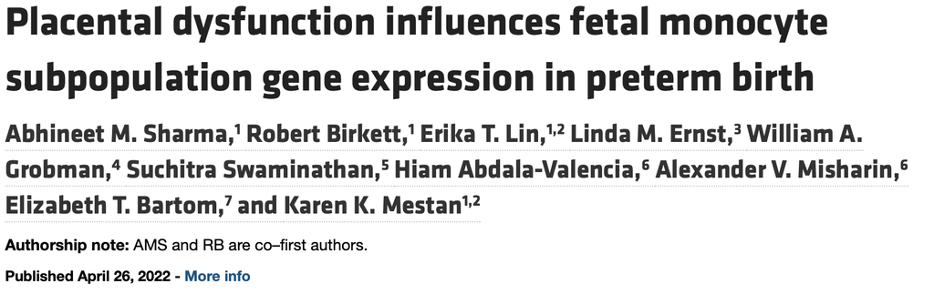

**Dataset:** GSE195727 **Purpose:** Identify differences in gene expression profiles in fetal monocytes - cells that persist and differentiate postnatally - according to distinct placental histologic domains. **Methods:** We first isolated classical and intermediate monocyte subsets via FACS and performed transcriptomic profiling of 140 samples (70 classical (cMNC) and 70 intermediate monocyte (iMNC) samples) using bulk RNA-Seq.

# PCA

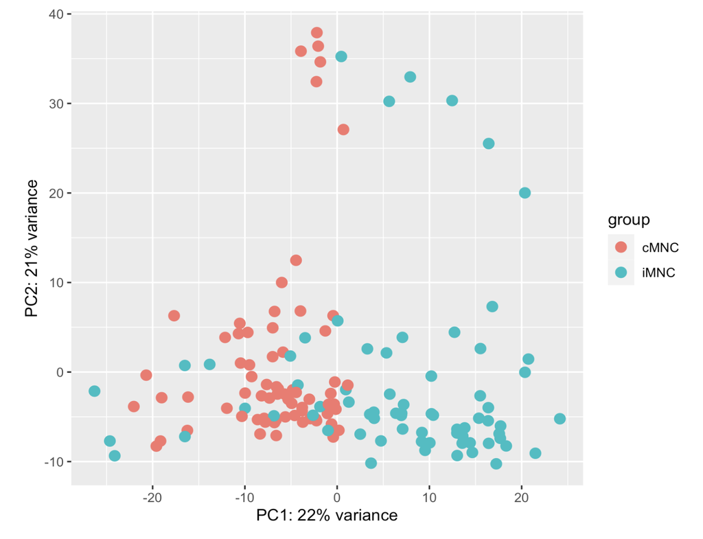

Principal component analysis shows a distinct speration of two cell types. We can see first component explaning 22% of vairance and spliting the cells in two clusters.

# Quality Control with NOISeq

Before analysing the dataset, the first step was to perfom a quality tests of the samples.

# Biotype detection

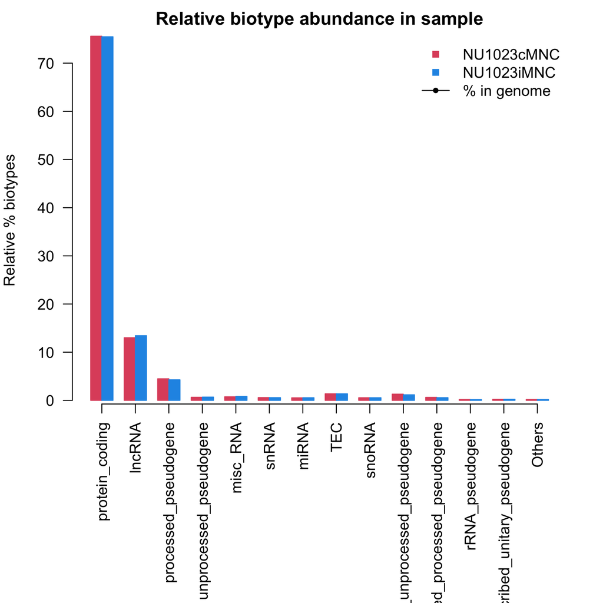

Above figure shows the relative abundance of biotypes in the two samples compared. In RNA-seq, it is expected that most of the genes will be protein-coding so detecting an enrichment in the sample of any other biotype could point to a potential contamination or at least provide information on the sample composition to take decision on the type of analysis to be performed.

# Counts per million

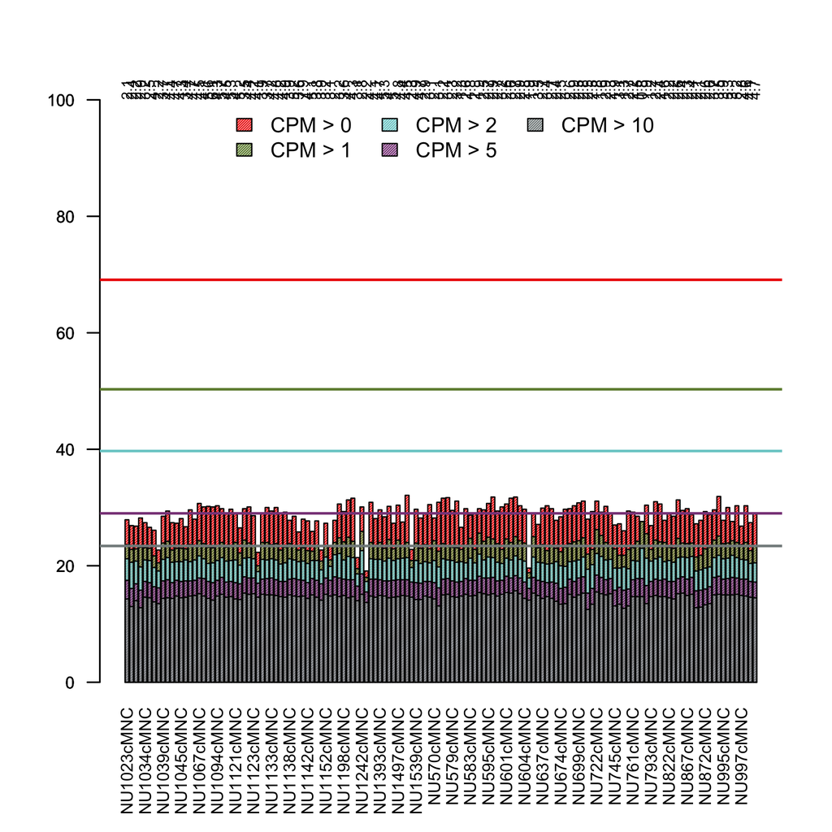

Features with low counts are, in general, less reliable and may introduce noise in the data. The above figure helps to decide the threshold to remove low-count features by indicating the proportion of such features that are present in our data.

# Differential Expression

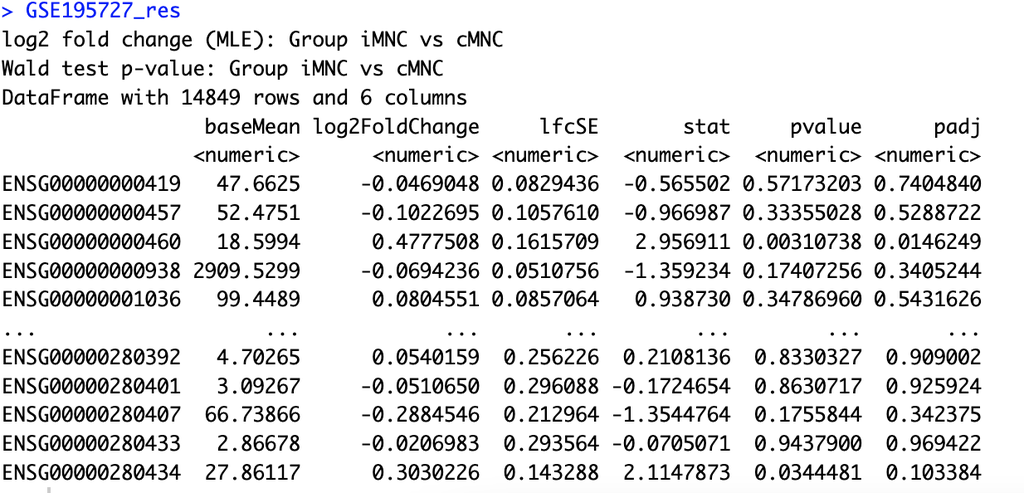

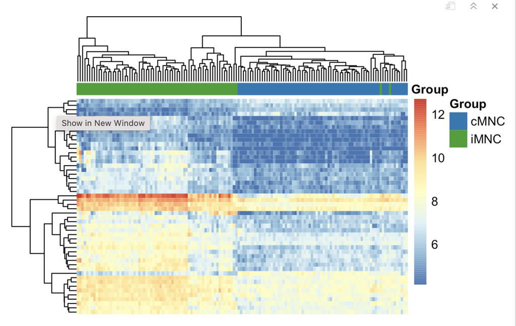

The above heatmap shows top 50 differentially expressed genes.

# Functional Enrichment

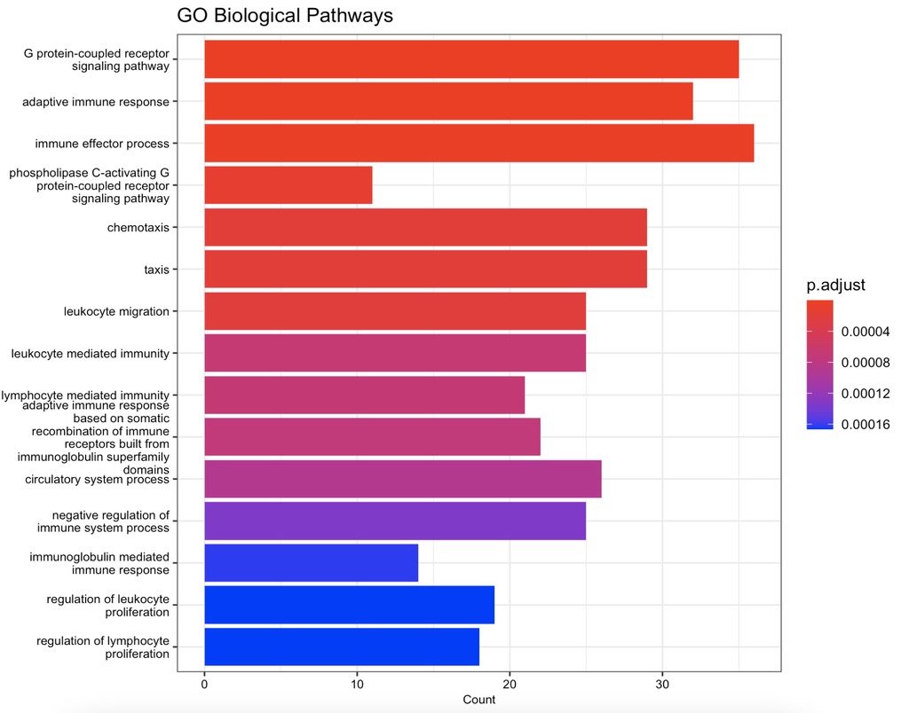

# Conclusions

Transcriptomic profiling of cord blood monocyte subsets identifies cell type–specific changes associated with different domains of placental pathology.